# Cervix Microsimulation Model Follow-Up Document

### The the main microsimulation function, `MicroSim`

This is a modified version of [Krijkamp et al (2018)](https://journals.sagepub.com/doi/abs/10.1177/0272989X18754513) where I have extended the number of individual states to 12 and have included age-dependent transition matrices.

```r
MicroSim <- function(v_M_1, n_i, n_t, v_n, d_c, d_e, TR_out = TRUE,
                     TS_out = TRUE, Trt = FALSE, seed = 1, Pmatrix) {
  ## Debuging:
  #TR_out = TRUE; TS_out = TRUE; Trt = FALSE; seed = 1

  #Arguments:
  # v_M_1:   vector of initial states for individuals
  # n_i:     number of individuals
  # n_t:     total number of cycles to run the model
  # v_n:     vector of health state names
  # d_c:     discount rate for costs
  # d_e:     discount rate for health outcome (QALYs)
  # TR_out:  should the output include a Microsimulation trace?
  #          (default is TRUE)
  # TS_out:  should the output include a matrix of transitions between states?
  #          (default is TRUE)
  # Trt:     are the n.i individuals receiving treatment? (scalar with a Boolean
  #          value, default is FALSE)
  # seed:    starting seed number for random number generator (default is 1)
  # Makes use of:
  # Probs:   function for the estimation of transition probabilities
  # Costs:   function for the estimation of cost state vamatrix: Matrix of
  # tranistion probabilities for each sim cycle.
  # Effs:    function for the estimation of state specific health outcomes (QALYs)
  # Pmatrix: Matrix of transition probabilities for each sim cycle.

  # Symptomatic individuals are those who, while in a cancer state (FIGO I-IV),
  # develop symptoms according to the probability vector `figoSymProb`. It is
  # assumed that all individuals who develop symptoms will visit a doctor. This
  # event incurs a one-time, lifetime cost (applicable only once, upon diagnosis).
  #symptomatics <- data.frame()
  symptomatics <-
    data.frame(ID = integer(), TimeStep = integer(),
               DiagnosedState = character(),
               RecoveredFromState = logical(), stringsAsFactors = FALSE)


  #v_dwc <- 1 / (1 + d_c) ^ (0:n_t)   # calculate the cost discount weight based
  v_dwc <- 1 / (1 + d_c) ^ (0:(n_t-1))   # calculate the cost discount weight based
  # on the discount rate d_c
  print(length(v_dwc))

  #v_dwe <- 1 / (1 + d_e) ^ (0:n_t)   # calculate the QALY discount weight based
  v_dwe <- 1 / (1 + d_e) ^ (0:(n_t-1))   # calculate the QALY discount weight based
  # on the discount rate d.e

  # Create the matrix capturing the state name/costs/health outcomes
  # for all individuals at each time point:
  #m_M <- m_C <- m_E <-  matrix(nrow = n_i, ncol = n_t + 1,
  m_M <- m_C <- m_E <-  matrix(nrow = n_i, ncol = (n_t + 1),
                               #dimnames = list(paste("ind", 1:n_i, sep = " "),
                               dimnames = list( 1:n_i,
                                                paste0("cycle_", 1:(n_t + 1), sep = "")))

  m_M[, 1] <- v_M_1                  # indicate the initial health state

  set.seed(seed)                     # set the seed for every individual for the
  # random number generator

  m_C[, 1] <- Costs_per_Cancer_Diag(M_it = m_M[, 1], # estimate costs per individual for the
                                    symptomatics = symptomatics,
                                    time_iteration = 1,
                                    cost_Vec =       # initial health state
                                      cost_Vec,
                                    Trt)
  print(v_n)
  m_E[, 1] <- Effs(m_M[, 1], Trt, utilityCoefs = utilityCoefs)  # estimate QALYs
  # per individual
  # for the initial
  # health state


  # new code:
  stored_list <- list()


  ######################## run over all the cycles #############################
  for (t in 1:(n_t)) {
    ############################################################################
    # Select the transition matrix based on the cycle `n_t`:
    # Since our age intervals start at 10 years old,
    # `age_in_loop` is calculated as `t + 10 * age_factor(cycle_period)`.
    age_in_loop <- t + 10
    # Choose corresponding transition matrix according current age:
    ## DONT USE it for cycle_period = "1yr"
    #my_age_prob_matrix <- my_Probs %>%
    #  dplyr::filter(Lower <=
    #                  (age_in_loop / age_factor(cycle_period)) &
    #                  Larger >= (age_in_loop / age_factor(cycle_period)) %>%
    #                  floor())
    my_age_prob_matrix <- my_Probs %>%
      dplyr::filter(Lower <= age_in_loop  &
                      Larger >= age_in_loop)

    # Add colnames and update `v_n`:
    rownames(my_age_prob_matrix) <- v_n <<-
      my_age_prob_matrix %>%
      dplyr::select(-c(Age.group, Lower, Larger)) %>%
      colnames()
    ############################################################################

    ## Check what's the cycle period and modify transitions accordingly:
    #my_age_prob_matrix <-
    #  convert_matrix_to_proper_transition(my_age_prob_matrix = my_age_prob_matrix,
    #                                       cycle_period = cycle_period)
    # update/correct n_s (<<- let change variable from inside a function):
    n_s  <<- length(v_n)

    ############################################################################
    #new code:
    new_entries <- diagnose_column(m_M[, t], t)

    if (!is.null(new_entries)) {
      stored_list[[t]] <- new_entries
    }

    if (nrow(new_entries) > 0) {
      symptomatics <- bind_rows(symptomatics, new_entries)
    }

    ## Debugging:
    ## Ensure M_it has no NA values
    #m_M[is.na(m_M)] <- "H"  # Or any other default state that makes sense
    ############################################################################


    ############################################################################
    # Extract the transition probabilities of each individuals at cycle t
    # given the individual current state and the corresponding
    # transition probability matrix that depends on age:
    ## Debugging:
    #cat("The time step is", t, "\n")
    m_P <- Probs(M_it =  m_M[, t], my_Probs = my_age_prob_matrix)

    m_M[, t + 1] <- samplev(probs = m_P, m = 1)  # sample the next health state
    # and store that state in
    # matrix m_M
    ############################################################################


    # m_M[, t + 1] <- update_column(m_M[, t], new_entries)
    next_col <- m_M[, t + 1]
    next_col <- update_column(m_M[, t], new_entries, next_col)

    # Ensure next_col updates are preserved after sampling
    m_M[, t + 1] <- ifelse(next_col == "Survival", "Survival", m_M[, t + 1])


    ############################################################################
    ## costs per CC diagnose at time t + 1.
    m_C[, t ] <-                              # estimate costs per individual
      Costs_per_Cancer_Diag(M_it = m_M[, t],  # during cycle t + 1
                            symptomatics = symptomatics,
                            time_iteration = t,
                            cost_Vec = cost_Vec,    # conditional on treatment
                            Trt)


    m_E[, t + 1] <-                              # estimate QALYs per individual
      Effs( m_M[, t + 1], Trt,
            utilityCoefs = utilityCoefs)                   # during cycle t + 1
    ############################################################################

    # conditional on treatment
    cat('\r', paste(round(t/n_t * 100),          # display the
                    "% done", sep = " "))        # progress of  the simulation
  }
  ######################## close loop for cycles ###############################

  # Combine stored entries into a single data frame
  symptomatics <- bind_rows(stored_list)
  tc <- m_C[,1:n_t] %*% v_dwc       # total (discounted) cost per individual
  te <- m_E[,1:n_t] %*% v_dwe       # total (discounted) QALYs per individual

  tc_hat <- mean(tc)        # average (discounted) cost
  te_hat <- mean(te)        # average (discounted) QALYs

  if (TS_out == TRUE) {  # create a matrix of transitions across states
    TS <- paste(m_M, cbind(m_M[, -1], NA), sep = "->") # transitions from one
    # state to the other

    TS <- matrix(TS, nrow = n_i)
    rownames(TS) <- paste("Ind",   1:n_i, sep = " ")   # name the rows
    #colnames(TS) <- paste("cycle", 1:n_t, sep = " ")   # name the columns
    colnames(TS) <- paste0("cycle_", 1:(n_t + 1), sep = "")   # name the columns
  } else {
    TS <- NULL
  }

  if (TR_out == TRUE) {
    TR <- t(apply(m_M, 2,
                  function(x) table(factor(x, levels = v_n, ordered = TRUE))))
    #TR <- TR / n_i                                   # create a distribution
    # trace

    rownames(TR) <- paste("cycle", 1:(n_t + 1), sep = "_") # name the rows
    colnames(TR) <- v_n                              # name the columns
  } else {
    TR <- NULL
  }

  # if TS_out == TRUE we can then compute the number of new cases for each type
  # of cancer state per time (cycle). A new case of cancer state X in time t
  # is defined as an individual transition to this state X provided the
  # individual was not in that state X a time t-1.
  # NOTE that the TR output display individual transitions at each cycle t
  # that are going to occur at t + 1. That is, "XX->YY" in cycle t meant that the
  # corresponding individual is in state "XX" in t and is transiting to state
  # "YY" in t + 1.
  # A character with all transitions:
  transitions <-
    TS %>%
    as_tibble() %>%
    pivot_longer(everything(), names_to = "column") %>%
    distinct(value) %>%
    unique() %>%
    as.list() %>%
    unlist()

  if(TS_out == TRUE){
    Tot_Trans_per_t <- t(apply(TS, 2,
                               function(x) table(factor(x, levels = transitions, ordered = TRUE))))
    # trace
    rownames(Tot_Trans_per_t) <- paste0("cycle_", 1:(n_t + 1), sep = "") # name the rows
  } else {
    Tot_Trans_per_t <- NULL
  }

  # New cases:
  new_CIN1 <- new_cases_2(state1 = "HR.HPV.infection", state2 = "CIN1",
                          Tot_Trans_per_t = Tot_Trans_per_t)

  new_CIN2 <- new_cases_2(state1 = "CIN1", state2 = "CIN2",
                          Tot_Trans_per_t = Tot_Trans_per_t)

  new_CIN3 <- new_cases_2(state1 = "CIN2", state2 = "CIN3",
                          Tot_Trans_per_t = Tot_Trans_per_t)

  new_Cancer <- new_cases_2(state1 = "CIN3", state2 = "FIGO.I",
                          Tot_Trans_per_t = Tot_Trans_per_t)


  # Store the results from the simulation in a list
  results <- list(m_M = m_M, m_C = m_C, m_E = m_E, tc = tc, te = te,
                  tc_hat = tc_hat, te_hat = te_hat,
                  TS = TS, TR = TR,
                  Tot_Trans_per_t = Tot_Trans_per_t,
                  symptomatics = symptomatics,
                  new_CIN1 = new_CIN1,
                  new_CIN2 = new_CIN2,
                  new_CIN3 = new_CIN3,
                  new_Cancer = new_Cancer
                  )


  return(results)  # return the results
}  # end of the MicroSim function
```

## Test simulation

### Perform cost-effectiveness analysis:

```r
###################### Cost-effectiveness analysis #############################
# store the mean costs (and MCSE) of each strategy in a new variable C (vector costs)
v_C  <- c(sim_no_trt$tc_hat, sim_trt$tc_hat)
sd_C <- c(sd(sim_no_trt$tc), sd(sim_trt$tc)) / sqrt(n_i)
# store the mean QALYs (and MCSE) of each strategy in a new variable E (vector effects)
v_E  <- c(sim_no_trt$te_hat, sim_trt$te_hat)
sd_E <- c(sd(sim_no_trt$te), sd(sim_trt$te)) / sqrt(n_i)

delta_C <- v_C[2] - v_C[1]                   # calculate incremental costs
delta_E <- v_E[2] - v_E[1]                   # calculate incremental QALYs
# Monte Carlo Squared Error (MCSE) of incremental costs:
sd_delta_E <- sd(sim_trt$te - sim_no_trt$te) / sqrt(n_i)
# Monte Carlo Squared Error (MCSE) of incremental QALYs:
sd_delta_C <- sd(sim_trt$tc - sim_no_trt$tc) / sqrt(n_i)
ICER    <- delta_C / delta_E                 # calculate the ICER
results <- c(delta_C, delta_E, ICER)         # store the values in a new variable


# Create full incremental cost-effectiveness analysis table
table_micro <- data.frame(
  c(round(v_C, 0),  ""),           # costs per arm
  c(round(sd_C, 0), ""),           # MCSE for costs
  c(round(v_E, 3),  ""),           # health outcomes per arm
  c(round(sd_E, 3), ""),           # MCSE for health outcomes
  c("", round(delta_C, 0),   ""),  # incremental costs
  c("", round(sd_delta_C, 0),""),  # MCSE for incremental costs
  c("", round(delta_E, 3),   ""),  # incremental QALYs
  c("", round(sd_delta_E, 3),""),  # MCSE for health outcomes (QALYs) gained
  c("", round(ICER, 0),      "")   # ICER
)
# name the rows:
rownames(table_micro) <- c(v_Trt, "* are MCSE values")
# name the columns:
colnames(table_micro) <-
  c("Costs", "*",  "QALYs", "*", "Incremental Costs",
    "*", "QALYs Gained", "*", "ICER")
table_micro  # print the table
```

|  | Costs | * | QALYs | * | Incremental Costs | * | QALYs Gained | * | ICER |
| --- | --- | --- | --- | --- | --- | --- | --- | --- | --- |
| No Treatment | 24 | 0 | 29.788 | 0.002 |  |  |  |  |  |
| Treatment | 25 | 0 | 29.788 | 0.002 | 1 | 1 | 0 | 0.002 | -1539 |
| * are MCSE values |  |  |  |  |  |  |  |  |  |

### Plotting routines: simulation curves

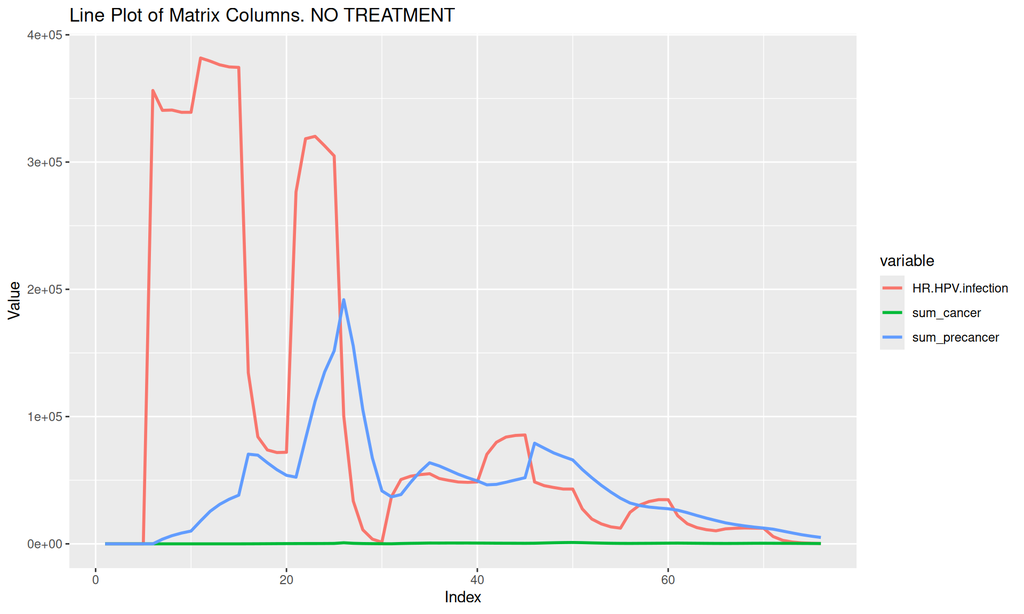

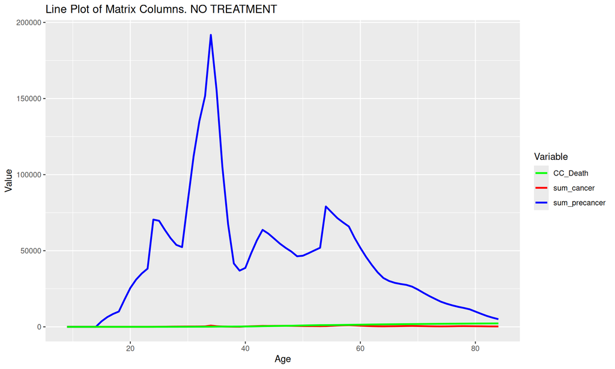

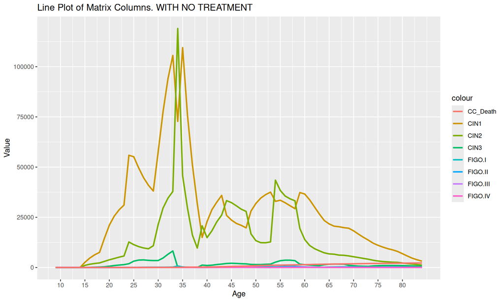

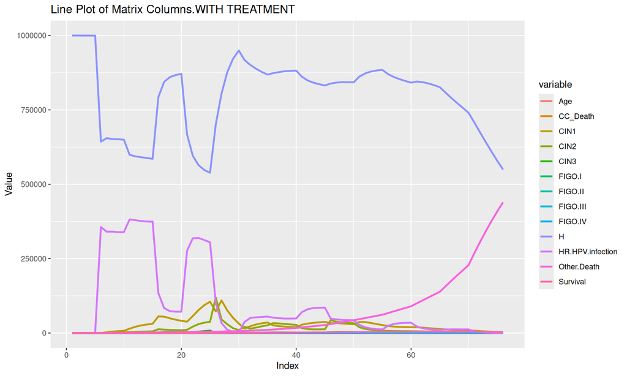

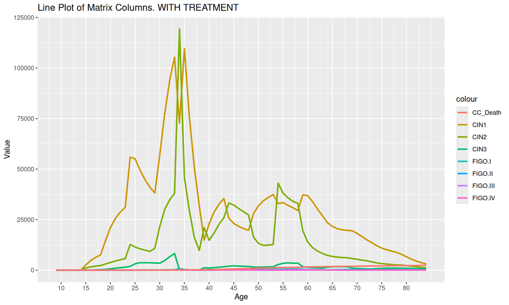

### Comparing microsimulation with Markov cohort simulations.

Given the output of a Markov cohort model with a 12-state structure and 15 age-dependent transition matrices, I proceeded to compare both simulations. I did this by aggregating individuals from the microsimulation and comparing the results with the corresponding cohort model outcomes.

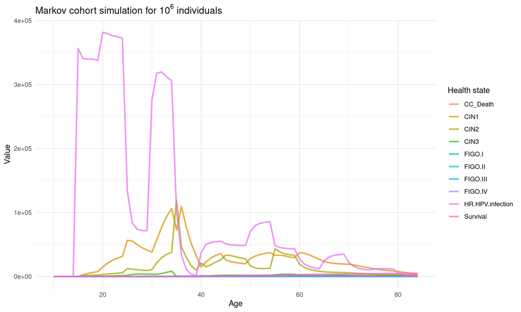

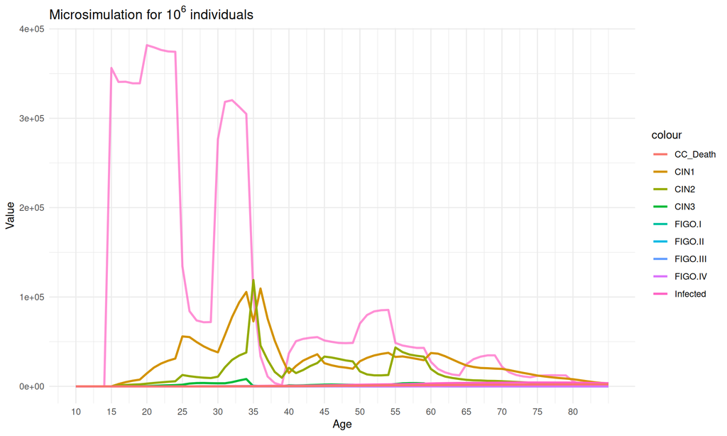

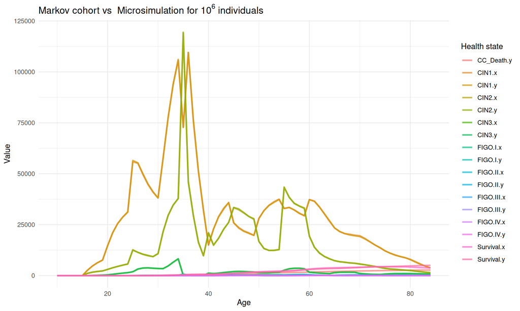

### New cases

Now I compare the new cases of some microsimulation model states to the ones coming from the Markov cohort model with the same probabilistic structure. In the microsimulation a new case of particular health-state at particular time $t$ is defined as an individual transition to that state provided the individual was in any different state in the previous time $t-1$.

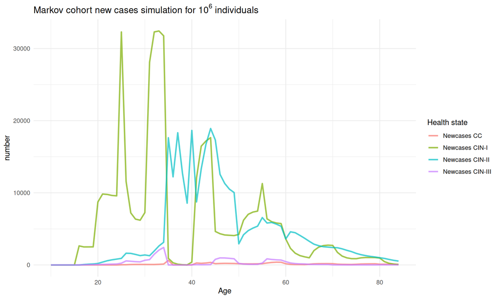

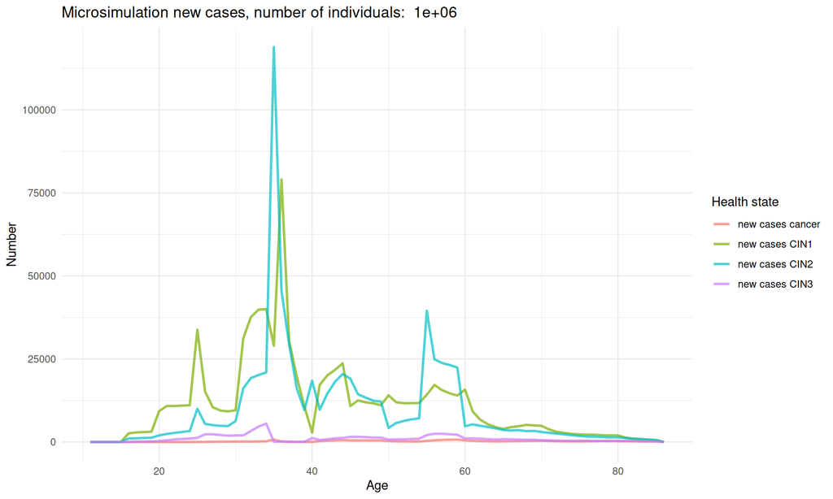

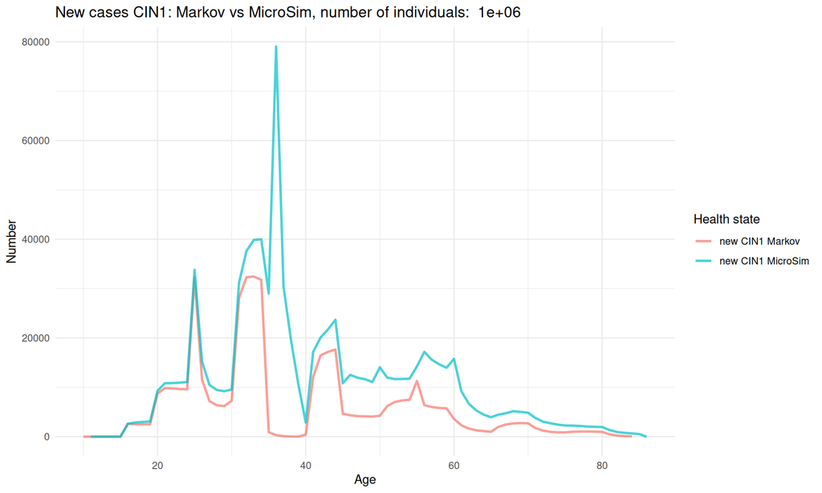

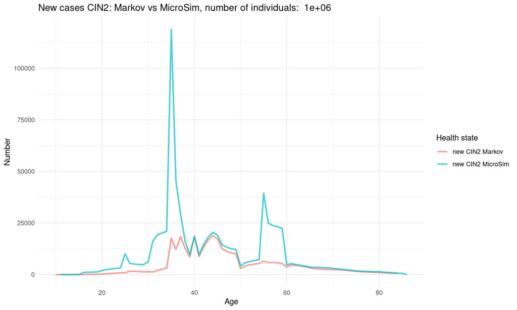

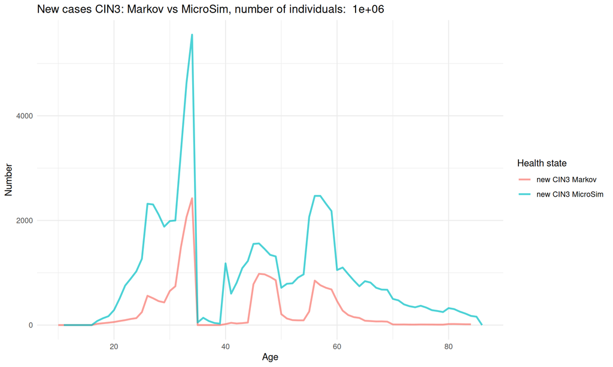

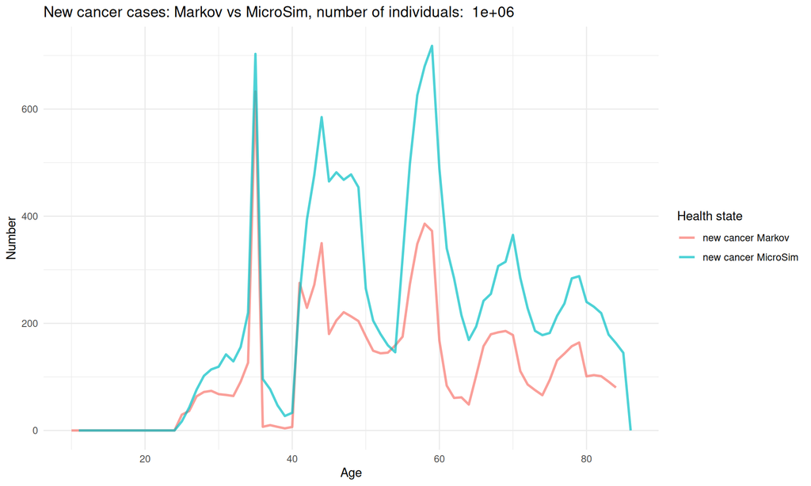

#### Corrected new cases:

Here I plot new cases of `CIN1`as only individual transitions of the type `HR.HPV.infection->CIN1`, i.e. only transitions coming from infections and nothing more. Similarly newcases of `CIN2` are the only transitions of the type `CIN1->CIN2`, new cases of `CIN3`are `CIN2->CIN3` and new cancers are only transitions `CIN3->FIGO-I`

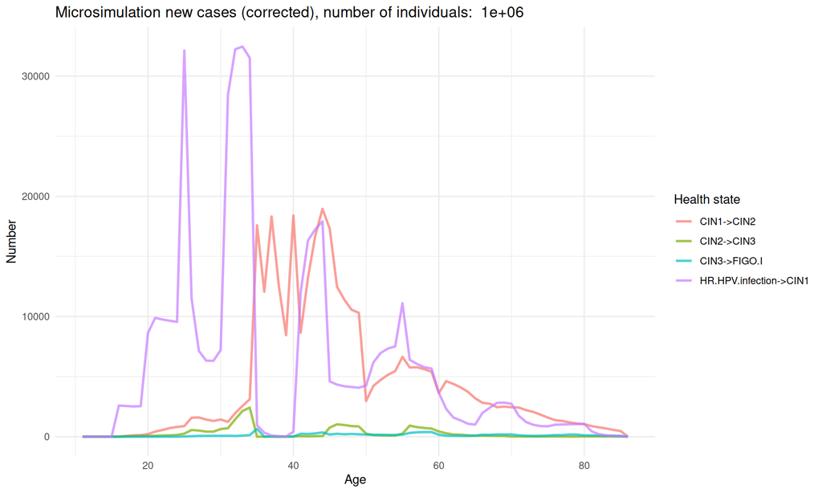

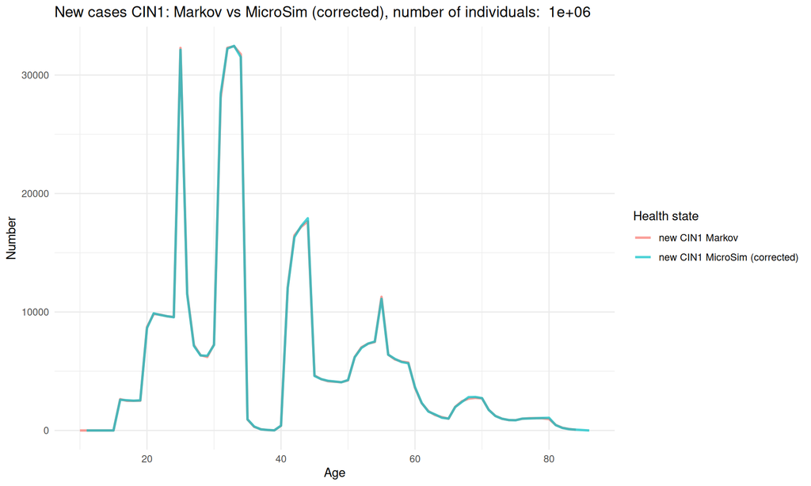

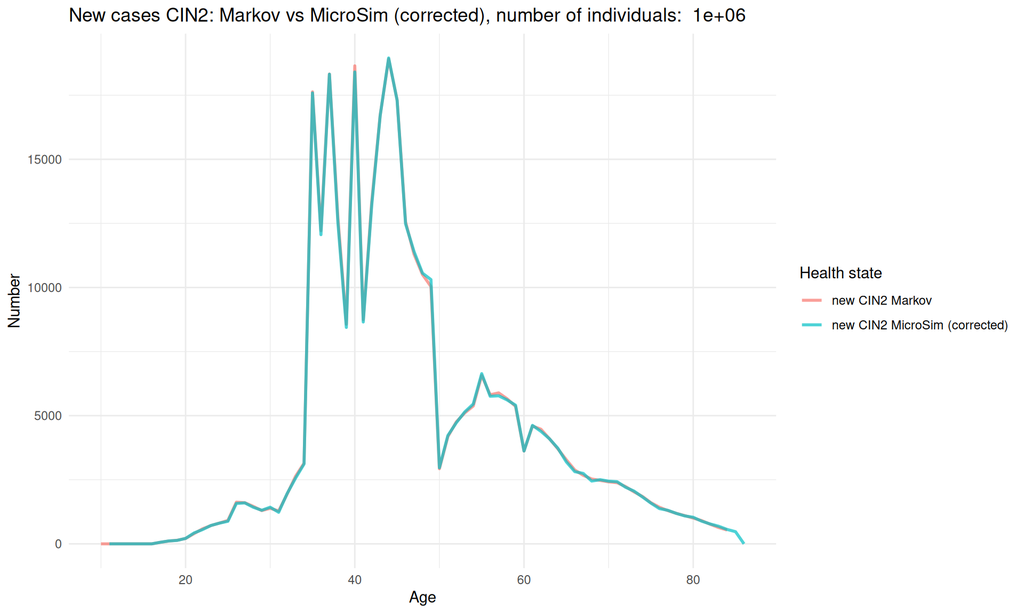

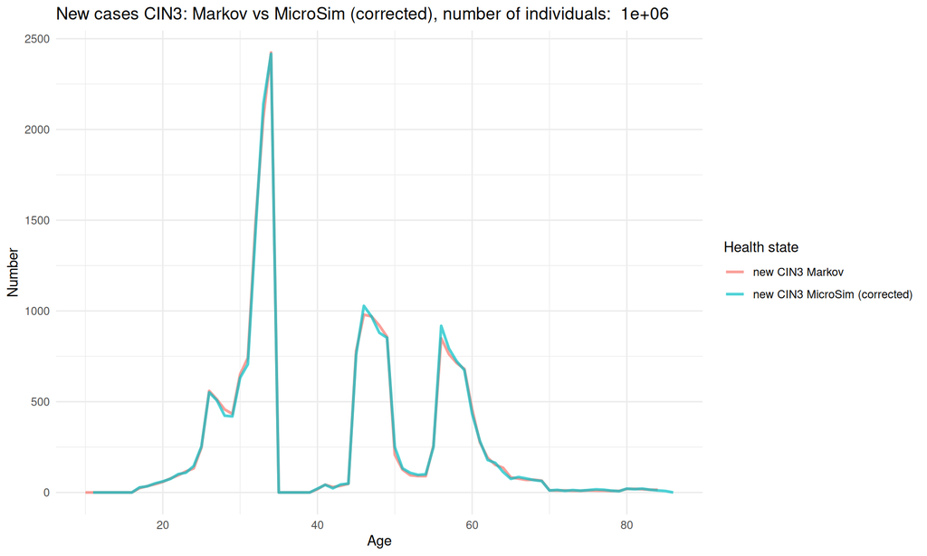

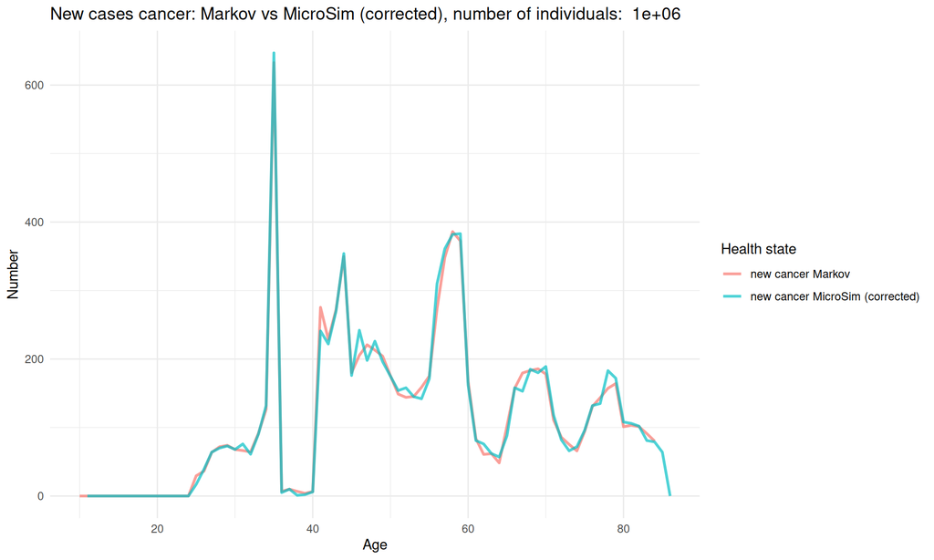